# Classical Tests

Guochun Shen  
Thu Apr 10 21:34:23 2014

### Occam's razor

There is absolutely no point in carring out an analysis that is **more complicated than it needs to be**.

Simplest is best.

### Single Samples

Typical qestions about inference from the data:

- what is the mean value?
- is the mean value significantly different from current expectation or theory?
- what is the level of uncertainty associated with our estimate of the mean value?

### Single Samples

In order to be reasonably confident that our inferences are correct, we need to establish some facts about the distribution of the data:

- Are the values normally distributed or not?
- Are there outliers in the data?
- If data were collected over a period of time, is there evidence for serial correlation?

### Data summary

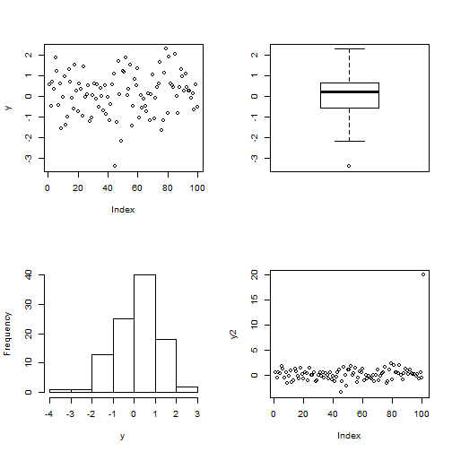

```r
par(mfrow=c(2,2))
y=rnorm(100)
plot(y)
boxplot(y)
hist(y,main="")
y2=y
y2[101]=20
plot(y2)
```

### Data summary

```r
summary(y)
```

```
   Min. 1st Qu.  Median    Mean 3rd Qu.    Max.
 -3.390  -0.548   0.193   0.122   0.626   2.290
```

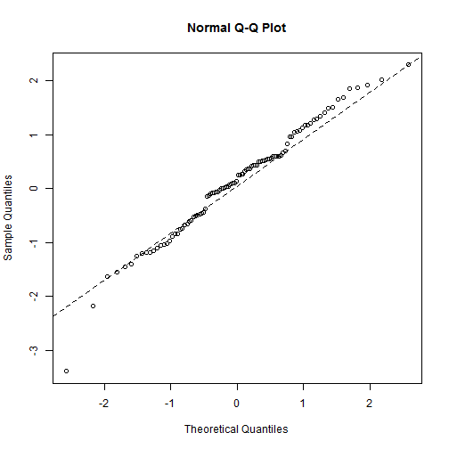

```r
qqnorm(y)
qqline(y,lty=2)
```

### Test for normality

Shapiro-Wilk Normality Test

```r
shapiro.test(y)
```

```
    Shapiro-Wilk normality test

data:  y
W = 0.9835, p-value = 0.2474
```

```r
x=exp(rnorm(30))
shapiro.test(x)
```

```
    Shapiro-Wilk normality test

data:  x
W = 0.5378, p-value = 1.375e-08
```

### Test the mean against expectation

```r
x=1+rnorm(100)
```

Does the mean of x significantly different with 0?

### Test the mean against expectation

**Student's t-Test**

```r
t.test(x,mu=0)
```

```
    One Sample t-test

data:  x
t = 12.91, df = 99, p-value < 2.2e-16
alternative hypothesis: true mean is not equal to 0
95 percent confidence interval:
 1.073 1.462
sample estimates:
mean of x
    1.268
```

### Test the mean against expectation

```r
y=1+exp(rnorm(100))
```

Does the mean of y significantly different with 1?

### Test the mean against expectation

When distribution of the data/error is non-normality:  
**Wilcoxon Signed Rank Test**

```r
wilcox.test(y,mu=1)
```

```
    Wilcoxon signed rank test with continuity correction

data:  y
V = 5050, p-value < 2.2e-16
alternative hypothesis: true location is not equal to 1
```

### Two samples

The classical tests for two samples includes:

- comparing two variances (Fisher's *F*)
- comparing two sample means with normal errors (Student's t test)
- comparing two means with non-normal errors (Wilcoxon's rank test)
- comparing two proportions (the binomial test)
- correlating two variables (Pearson's or Spearman's rank correlation)
- testing for independence of two variables in a contingency table (chi-squared)

### Comparing two variances- Fisher's F test

```r
x=rnorm(100,mean=1,sd=2)
y=rnorm(89,mean=0,sd=10)
var.test(x,y)
```

```
    F test to compare two variances

data:  x and y
F = 0.0423, num df = 99, denom df = 88, p-value < 2.2e-16
alternative hypothesis: true ratio of variances is not equal to 1
95 percent confidence interval:
 0.02807 0.06356
sample estimates:
ratio of variances
           0.04234
```

### Comparing two variances-Fligner-Killeen test

it is a non-parametric test, insensitive to outliers.

```r
y=c(x,y)
g=as.factor(rep(c("x","y"),c(100,89)))
fligner.test(y~g)
```

```
    Fligner-Killeen test of homogeneity of variances

data:  y by g
Fligner-Killeen:med chi-squared = 81.94, df = 1, p-value < 2.2e-16
```

### Comparing two means

There are two classical tests for comparing two sample means:

- Student's test when the samples are independent, the variances constant, and the errors are normally distributed;
- Wilcoxon's rank-sum test when the samples are independent but the errors are not normally distributed.

### Comparing two means- Student's t test

Student was the pseudonym of W.S. Gossett who published his influential paper in Biometrika in 1908. The archaic employment laws in place at the time allowed his employer, the Guinness Brewing Company, to prevent him publishing independent work under his own name.

Student’s t distribution, later perfected by R.A. Fisher, revolutionized the study of small-sample statistics where inferences need to be made on the basis of the sample variance s<sup>2</sup> with the population variance σ<sup>2</sup> unknown (indeed, usually unknowable).

### Comparing two means- Student's t test

```r
r1=t.test(x,y)
r1
```

```
    Welch Two Sample t-test

data:  x and y
t = 2.249, df = 240.5, p-value = 0.02539
alternative hypothesis: true difference in means is not equal to 0
95 percent confidence interval:
 0.1438 2.1710
sample estimates:
mean of x mean of y
  1.09861  -0.05879
```

### Comparing two means- Wilcoxon rank-sum test

```r
r2=wilcox.test(x,y)
r2
```

```
    Wilcoxon rank sum test with continuity correction

data:  x and y
W = 10154, p-value = 0.2979
alternative hypothesis: true location shift is not equal to 0
```

### Comparing two means

The Wilcoxon test is aid to be conservative: if a difference is significant under a Wilcoxon test it would be even more significant under a *t* test.

```r
r1$p.value # pvalue of Student t test
```

```
[1] 0.02539
```

```r
r2$p.value # pvalue of Wilcoxon test
```

```
[1] 0.2979
```

### Comparing two means - paired samples

Sometimes, two-sample data come from paired observations. In this case, we might expect a correlation between the two measurements, because they were either made on the same individual, or taken from the same location.

### Comparing two means - paired samples

The following data are a composite biodiversity score based on a kick sample of aquatic invertebrates:

```r
streams = read.table("./data/streams.txt",header=T)
attach(streams)
names(streams)
```

```
[1] "down" "up"
```

The elements are paired because the two samples were taken on the same river, one upstream and one downstream from the same sewage outfall.

### Comparing two means - paired samples

If we ignore the fact that the samples are paired, it appears that the sewage outfall has no impact on biodiversity score (p = 0.6856):

```r
t.test(down,up)
```

```
    Welch Two Sample t-test

data:  down and up
t = -0.4088, df = 29.75, p-value = 0.6856
alternative hypothesis: true difference in means is not equal to 0
95 percent confidence interval:
 -5.248  3.498
sample estimates:
mean of x mean of y
    12.50     13.38
```

### Comparing two means - paired samples

However, if we allow that the samples are paired, the picture is completely different:

```r
t.test(down,up,paired=TRUE)
```

```
    Paired t-test

data:  down and up
t = -3.05, df = 15, p-value = 0.0081
alternative hypothesis: true difference in means is not equal to 0
95 percent confidence interval:
 -1.4864 -0.2636
sample estimates:
mean of the differences
                 -0.875
```

### The sign test

This is one of the simplest of all statistical tests. Suppose that you cannot measure a difference, but you can see it.

For example:

Flip a coin 9 times, one heads and 8 tails. Then can we say the coin is not fair?

### The sign test

```r
binom.test(1,9)
```

```
    Exact binomial test

data:  1 and 9
number of successes = 1, number of trials = 9, p-value = 0.03906
alternative hypothesis: true probability of success is not equal to 0.5
95 percent confidence interval:
 0.002809 0.482497
sample estimates:
probability of success
                0.1111
```

### compare two proportions

Suppose that only four females were promoted, compared to 196 men. Is this an example of blatant sexism, as it might appear at first glance? Before we can judge, of course, we need to know the number of male and female candidates. It turns out that 196 men were promoted out of 3270 candidates, compared with 4 promotions out of only 40 candidates for the women. Now, if anything, it looks like the females did better than males in the promotion round (10% success for women versus 6% success for men).  
The question then arises as to whether the apparent positive discrimination in favour of women is statistically significant, or whether this sort of difference could arise through chance alone.

### compare two proportions

```r
prop.test(c(4,196),c(40,3270))
```

```
    2-sample test for equality of proportions with continuity
    correction

data:  c(4, 196) out of c(40, 3270)
X-squared = 0.5229, df = 1, p-value = 0.4696
alternative hypothesis: two.sided
95 percent confidence interval:
 -0.06592  0.14604
sample estimates:
 prop 1  prop 2
0.10000 0.05994
```

### Chi-squared contingency tables

A great deal of statistical information comes in the form of counts (whole numbers or integers): the number of animals that died, the number of branches on a tree, the number of days of frost, the number of companies that failed, the number of patients who died.

**The important question is whether the expected frequencies are significantly different from the observed frequencies.**

### Pearson's chi-squared test

The Pearson's Chi-squared test, \( \chi^2 \), is

\[ \chi^2=\sum{\frac{(O-E)^2}{E}} \]

where O is the observed frequency and E is the expected frequency.

The question is how big the value of chi-squared is to suggest a significant difference?

The reference point can be get by the R function **qchisq**

### contingency table

The contingencies in statistics, are all the events that could possibly happen. Acontingency table shows the counts of how many times each of the contingencies actually happened in a particular sample.

### contingency table

```r
count <- matrix(c(38,14,11,51),nrow=2)
count
```

```
     [,1] [,2]
[1,]   38   11
[2,]   14   51
```

```r
chisq.test(count)
```

```
    Pearson's Chi-squared test with Yates' continuity correction

data:  count
X-squared = 33.11, df = 1, p-value = 8.7e-09
```

### contingency table

unequal probabilities in the null hypothesis

```r
chisq.test(count,p=c(0.2,0.2,0.3,0.3))
```

```
    Pearson's Chi-squared test with Yates' continuity correction

data:  count
X-squared = 33.11, df = 1, p-value = 8.7e-09
```

### contingency table with small expected frequencies

When one or more of the expected frequencies is less than 4 then it is wrong to use Pearson’s chi-squared for your contingency table. This is because small expected values inflate the value of the test statistic, and it no longer can be assumed to follow the chi-squared distribution.

Instead, it is better to use **Fisher's exact test.**

### contingency table with small expected frequencies

```r
x = matrix(c(6,4,2,8),2,2)
fisher.test(x)
```

```
    Fisher's Exact Test for Count Data

data:  x
p-value = 0.1698
alternative hypothesis: true odds ratio is not equal to 1
95 percent confidence interval:
  0.6027 79.8309
sample estimates:
odds ratio
      5.43
```

### Kolmogorov–Smirnov test

It is an extremely simple test for asking one of two different questions:

- Are two sample distributions the same, or are they significantly different from one another in one or more (unspecified) ways?
- Does a particular sample distribution arise from a particular hypothesized distribution?

### Kolmogorov–Smirnov test

Examples:

```r
x <- rnorm(50)
y <- runif(30)
# Do x and y come from the same distribution?
ks.test(x, y)
```

```
    Two-sample Kolmogorov-Smirnov test

data:  x and y
D = 0.4333, p-value = 0.001154
alternative hypothesis: two-sided
```

### Kolmogorov–Smirnov test

Examples:

```r
y <- runif(30)
# Does x come from the normal distribution?
ks.test(y, "pnorm",mean(y),sd(y))
```

```
    One-sample Kolmogorov-Smirnov test

data:  y
D = 0.0882, p-value = 0.9578
alternative hypothesis: two-sided
```

### Kolmogorov–Smirnov test

But

```r
shapiro.test(y)
```

```
    Shapiro-Wilk normality test

data:  y
W = 0.9532, p-value = 0.206
```

### Power analysis

**The power of a test is the probability of rejecting the null hypothesis when it is false.**

it has to do with Type II errors: β is the probability of accepting the null hypothesis when it is false.

### Power analysis

In an ideal world, we would obviously make β as small as possible. But there is a snag. The smaller we make the probability of committing a Type II error, the greater we make the probability of committing a Type I error, and rejecting the null hypothesis when, in fact, it is correct. This is a classic trade-off. A compromise is called for.

Most statisticians work with α = 0.05 and β = 0.2. The power of a test is defined as 1 − β = 0.8 under the standard assumptions.

### Power analysis

Three R built-in functions:

- **power.t.test** power calculations for one- and two-sample t test;
- **power.prop.test** power calculations two-sample test for proportions;
- **power.anova.test** power calculations for balanced one-way ANOVA tests;

### Power analysis

Example 1:

What is the power of a test to detect a difference of 10% in one sample with 30 replicates when the mean is 20, and standard deviation is about 3.5?

### Power analysis

Example 1:

```r
power.t.test(n=30,delta=2,sd=3.5)
```

```
     Two-sample t test power calculation

              n = 30
          delta = 2
             sd = 3.5
      sig.level = 0.05
          power = 0.5857
    alternative = two.sided

NOTE: n is number in *each* group
```

### Power analysis

Example 2:

How many replicates do we need in each of two samples to detect a difference of 10% with power = 80% when the mean is 20 (i.e. delta=2.0) and standard deviation is about 3.5?

### Power analysis

Example 2:

```r
power.t.test(delta=2,sd=3.5,power=0.8)
```

```
     Two-sample t test power calculation

              n = 49.05
          delta = 2
             sd = 3.5
      sig.level = 0.05
          power = 0.8
    alternative = two.sided

NOTE: n is number in *each* group
```

### Power analysis

The power analysis can help you to archive a well designed experiment.

Before carrying out a power analysis, the work you need to do is to find values for the standard deviation (from the literature or by carrying out a pilot experiment) and the size of difference your want to detect (from discussions with your sponsor or your colleages).

### Permutation

All of the tests mentioned so far implicitely assume that **distribution of the random variable (or statistic) is known.**

However, it is quite often in the real world that distribution of the random variable is unknown, or too complex to follow any of the well-known probability distributions.

Then how can we test our expectations or hypotheses?

### Permutation

Permutation: instead of comparing the actual value of a test statistic to a standard statistic distribution, **the reference distribution is generated from the data themselves**.

The chief advantage is that one does not have to worry about the distributional assumptions of classical testing procedures.

Disadvantage is the extra computer time required to acturally perform a large number of permutations.

### Permutation

Typical steps of permutation test:

1. establish null hypothesis
2. choose a test statistic
3. build the distribution of the test statistic
4. statistical decision (e.g. p-value)

### Permutation

Example: Are x1 and x2 significantly correlated?

```r
x1=c(-2.31,1.06,
     1.38,-0.26,1.29,
     -1.31,0.41,-0.67
     ,-0.58,0.76)
x2=c(-1.08,1.03,
     0.24,-0.24,0.76,
     -0.57,-0.05,
     -1.28,1.04,0.9)
```

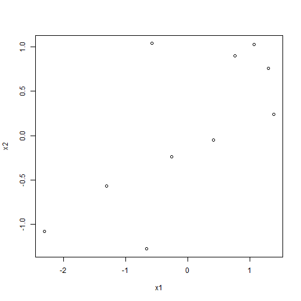

### Permutation

Example: Are x1 and x2 significantly correlated?

Step1: The null hypothesis

There is no significant correlation between x1 and x2.

It means: the correlation between x1 and x2 will not be changed if *order of elements in x1/x2 is changed* (permutation).

### Permutation

Example: Are x1 and x2 significantly correlated?

Step2: choose a test statistic

let's use pearson correlation coefficient r

\[ r=\frac{\sum_{i=1}^n{(X_i-\bar{X})(Y_i-\bar{Y}) }}{\sqrt{\sum_{i=1}^n{(X_i-\bar{X})^2} \sum_{i=1}^n{(Y_i-\bar{Y})^2}}} \]

```r
obs_r=cor(x1,x2,method="pearson")
obs_r
```

```
[1] 0.7016
```

### Permutation

Example: Are x1 and x2 significantly correlated?

Step3: build the distribution of the test statistic by permutation

```r
null_r=numeric()
for(i in 1:999){
  x1_null=sample(x1)
  null_r[i]=cor(x1_null,x2,method="pearson")
}
```

### Permutation

Example: Are x1 and x2 significantly correlated?

Step3: build the distribution of the test statistic by permutation

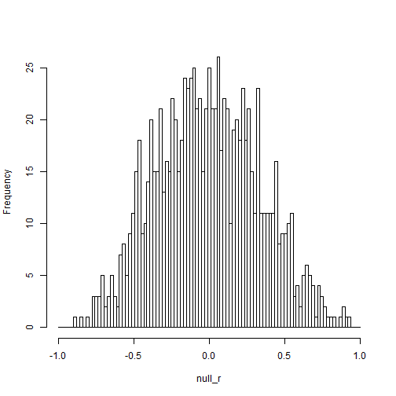

### Permutation

Example: Are x1 and x2 significantly correlated?

Step4: statistical decision (e.g. p-value)

one tail:

```r
sum(null_r>obs_r)/(1000)
```

```
[1] 0.018
```

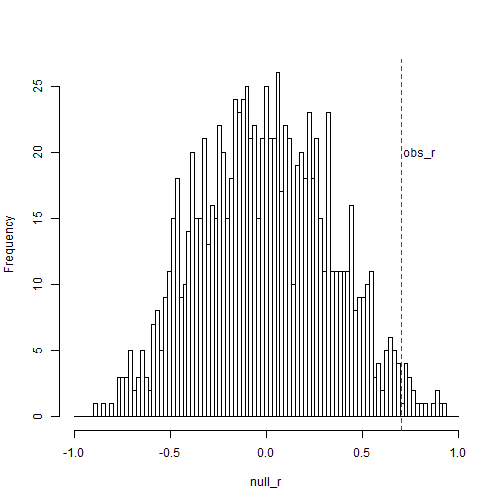

### Permutation

Example: Are x1 and x2 significantly correlated?

Step4: statistical decision (e.g. p-value)

two tails:

```r
sum(abs(null_r)>abs(obs_r))/(1000)
```

```
[1] 0.034
```

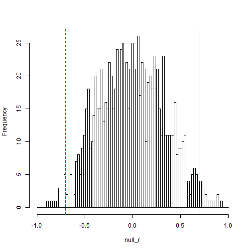

### Permutation

- complete permutation test
- sampled permutation test
- restricted permutation test

Monte Carlo

Jackknife

Bootstrap